# Plotting Basics with `Matplotlib` and `Seaborn`

Python programming

Data visualization

Matplotlib

Seaborn

This lesson introduces data visualization in Python using `Matplotlib` and `Seaborn`, showing how to build scatterplots, adjust aesthetics and customize labels to create clear figures.

Authors

Noor Sohail

Will Gammerdinger

Published

March 16, 2026

Keywords

Figures, Scatterplots, Aesthetics, Themes, Plot customization

Approximate time: 40 minutes

## Learning objectives

In this lesson, we will:

- Explain the concept of layering in plotting and how to build a plot step-by-step
- Create a scatterplot using `MatPlotLib` and customize its aesthetics with `Seaborn`
- Apply different themes to a plot and adjust axis labels and titles

## Overview of lesson

Plots are one of the best ways to communication and summarize results to others. With `Matplotlib` and `Seaborn`, you can create customizable visualizations from your data. Data scientists and researchers use these tools everyday to explore trends and create publication-ready figures for presentations and manuscripts. In this lesson, you will learn the basics of building a scatterplot and adjusting its aesthetics to give you the foundation for creating any plot you may want to generate in the future.

## Plotting basics

`MatPlotLib` is one of the most widely used plotting packages in Python. With it, we can create many different types of plots, including scatterplots, line plots, bar plots, boxplots and more. The important thing to remember is that you can slowly build upon your plot, adding different layers of information to create a more informative and visually appealing plot. So there is no need to create a perfect plot in one step!

We will start with drawing a simple x-y scatterplot of `mean_expression` versus `age_in_days` from `new_metadata`.

### Initialize a plot with `MatPlotLib`

First, we will import the `MatPlotLib` and `Pandas` libraries as well as load `new_metadata` that we created in the previous lesson:

```python
# Import libraries
import matplotlib.pyplot as plt
import pandas as pd

# Load the new metadata data frame that we created in the previous lesson
new_metadata = pd.read_csv("data/new_metadata.csv", index_col=0)

# Print out new_metadata
new_metadata
```

Table 1: DataFrame containing updated metadata for each of our 12 samples.

|  | genotype | celltype | replicate | mean_expression | age_in_days |
| --- | --- | --- | --- | --- | --- |
| sample1 | Wt | typeA | 1 | 10.266102 | 40 |
| sample2 | Wt | typeA | 2 | 10.849759 | 32 |
| sample3 | Wt | typeA | 3 | 9.452517 | 38 |
| sample4 | KO | typeA | 1 | 15.833872 | 35 |
| sample5 | KO | typeA | 2 | 15.590184 | 41 |
| sample6 | KO | typeA | 3 | 15.551529 | 32 |
| sample7 | Wt | typeB | 1 | 15.522219 | 34 |
| sample8 | Wt | typeB | 2 | 13.808281 | 26 |
| sample9 | Wt | typeB | 3 | 14.108399 | 28 |
| sample10 | KO | typeB | 1 | 10.743292 | 28 |
| sample11 | KO | typeB | 2 | 10.778318 | 30 |
| sample12 | KO | typeB | 3 | 9.754733 | 32 |

We will first initialize a plot by using the `figure()` function from `MatPlotLib`. Let us look at some of the arguments we can use with the `help()` function:

```python
# Look at the help for the figure function
help(plt.figure)
```

So first, we’ll create an empty plot of size 8 inches by 6 inches:

```python
# Initialize a plot with a specific size
plt.figure(figsize = (8, 6))

# Render the plot
plt.show()
```

**Note**

As we go through the lesson, you may notice that most plots will render just fine without `plt.show()`. `plt.show()` is a good practice to have in your plot’s code to explicitly state that you would like the figure to be created at this point. Certain computing set-ups require `plt.show()` in order to render an image, while others may get confused and attempt to overlay multiple plots without it. As a result, it is a good habit to use `plt.show()` to explicitly state where in the code you’d like your plot to be rendered.

### Adding a scatterplot layer

We will once again first initialize the plot with `figure()` and then add the scatterplot layer to the plot with `scatter()`. We need to specify where we are pulling the data to plot from, which in this case will be the `new_metadata` DataFrame, and the `x` and `y` values for our scatterplot, which in this case will be `age_in_days` for `x` and `mean_expression` for `y`.

The `plt.figure` and `plt.scatter` calls are connected because `MatPlotLib` commands build upon each other. The `plt.figure` command initializes the plot and sets the size, while the `plt.scatter` command adds the scatterplot layer to the existing plot. When we call these functions sequentially, we are building our plot layer by layer.

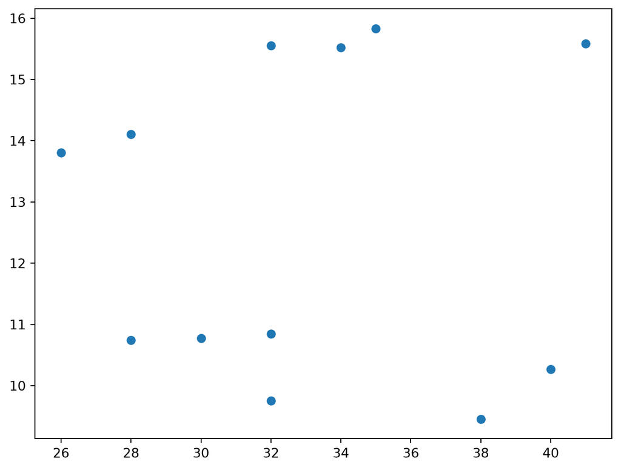

Figure 2: Scatterplot of age in days vs. mean expression.

```python
# Initialize a plot with a specific size
plt.figure(figsize = (8, 6))

# Add a scatterplot layer to the plot
plt.scatter(data = new_metadata,
            x = "age_in_days",
            y = "mean_expression")

# Render the plot
plt.show()
```

**NoteAlternative**

Instead of providing the `data` argument, you could specify the `x` and `y` axes as the given columns from `new_metadata`.

```python
# Initialize a plot with a specific size
plt.figure(figsize = (8, 6))

# Add a scatterplot layer to the plot
plt.scatter(x = new_metadata["age_in_days"],
            y = new_metadata["mean_expression"])

# Render the plot
plt.show()
```

Now that we have the required fundamentals, let’s add some extra details like color to the plot. We can color the points on the plot based on the genotype column with the `c` argument.

[output not shown]

[output cut: 48 more lines]

[output not shown]

[figure not shown]

Figure 3: Initial attempt to color the scatterplot of age in days vs. mean expression by genotype, which results in an error.

```python
# Initialize a plot with a specific size
plt.figure(figsize = (8, 6))

# Add a scatterplot layer to the plot, coloring points by genotype
plt.scatter(data = new_metadata,
            x = "age_in_days",
            y = "mean_expression",
            c = "genotype")

# Render the plot
plt.show()
```

**We are getting an error from trying to set the color.** This is because the `c` argument in `scatter()` expects a list of color values, but we are providing it with categorical data from the `genotype` column.

### Changing aesthetics

To work around the error from `plt.scatter`, we will instead use the `seaborn` package’s `scatterplot()` function and use the `hue` argument instead of `c`, which allows us to specify a categorical variable in order to color the plot points. The documentation for `seaborn.scatterplot()` is quite extensive and can be found [on their official website](https://seaborn.pydata.org/generated/seaborn.scatterplot.html).

You will notice that there are a default set of colors that we can use, so we do not have to specify a color. The legend and axis labels have also been automatically plotted for us!

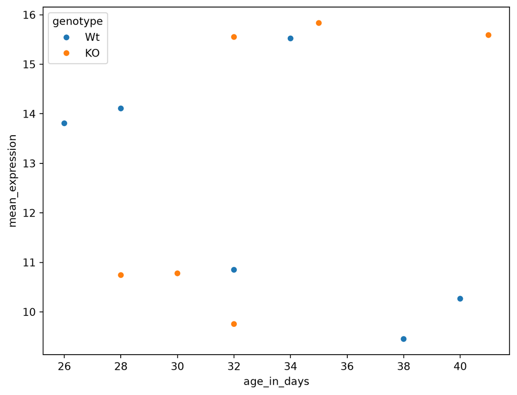

Figure 4: Scatterplot of age in days vs. mean expression, colored by genotype.

```python
# Import library
import seaborn as sns

# Initialize a plot with a specific size
plt.figure(figsize = (8, 6))

# Add a scatterplot layer to the plot, coloring points by genotype
sns.scatterplot(data = new_metadata,
                x = "age_in_days",
                y = "mean_expression",
                hue = "genotype")

# Render the plot
plt.show()
```

`seaborn` is a bit more flexible than `MatPlotLib` and allows us to easily add more aesthetics to our plot. You will oftentimes find yourself using a blend of both packages together to create the plot you want.

Let’s try to have both `celltype` and `genotype` represented on the plot. We can assign the `celltype` column to the `style` argument in `scatterplot()`, so each celltype is plotted with a different shaped data point.

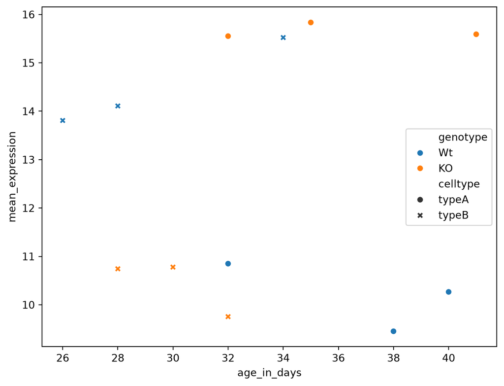

Figure 5: Scatterplot of age in days vs. mean expression, colored by genotype and shaped by celltype.

```python
# Initialize a plot with a specific size
plt.figure(figsize = (8, 6))

# Add a scatterplot layer to the plot, coloring points by genotype
sns.scatterplot(data = new_metadata,
                x = "age_in_days",
                y = "mean_expression",
                hue = "genotype",
                style = "celltype")

# Render the plot
plt.show()
```

**Note**

You may have noticed that the figure legend moved when we added our `style` argument. This is because there is an argument (`loc`) set within `plt.legend()` which allows you to direct the placement of the legend. It can take the value of one of nine possible locations (`'upper left'`, `'upper right'`, `'lower left'`, `'lower right'`, `'upper center'`, `'lower center'`, `'center left'`, `'center right'`, `'center'`) to determine where to place the legend. However, the default is a value of `'best'` which selects one of those nine possible locations, which minimizes the overlap of the legend on top of data. As a result of adding our `style` argument, it made the legend longer, which meant that it would be better placed is a different location in the plot to minimize overlap with the data points.

The data points are quite small. We can also adjust the `s` (size) of the data points within the `scatterplot()` function. Since we do not want the size of the data points to be scaled according to a column in `new_metadata`, we will just specify a number for this argument.

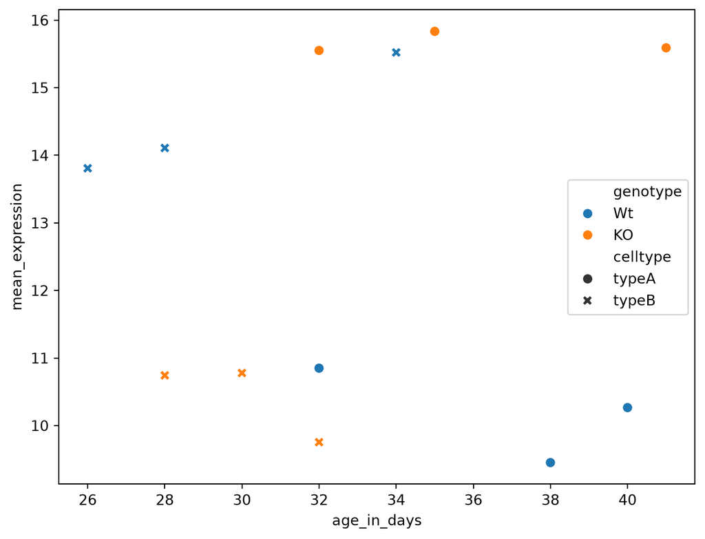

Figure 6: Scatterplot of age in days vs. mean expression, colored by genotype and shaped by celltype, with adjusted size.

```python
# Initialize a plot with a specific size
plt.figure(figsize = (8, 6))

# Add a scatterplot layer to the plot, coloring points by genotype
sns.scatterplot(data = new_metadata,
                x = "age_in_days",
                y = "mean_expression",
                hue = "genotype",
                style = "celltype",
                s = 50)

# Render the plot
plt.show()
```

### Themes

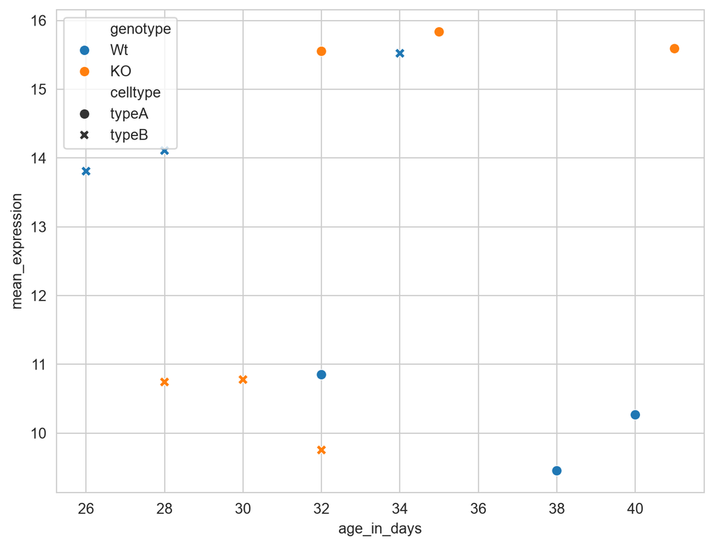

Figure 7: Scatterplot of age in days vs. mean expression, colored by genotype and shaped by celltype, with adjusted size and a different theme.

```python
# Set the theme to "whitegrid"
sns.set_style(style = "whitegrid")

# Initialize a plot with a specific size
plt.figure(figsize = (8, 6))

# Add a scatterplot layer to the plot, coloring points by genotype
sns.scatterplot(data = new_metadata,
                x = "age_in_days",
                y = "mean_expression",
                hue = "genotype",
                style = "celltype",
                s = 50)

# Render the plot
plt.show()
```

**NoteCustomizing themes**

You can also customize themes further with `rc_params` when you want to adjust specific elements of the theme. The documentation for `set_style()` can be found [on their official website](https://seaborn.pydata.org/generated/seaborn.set_style.html).

### Changing labels

The axis labels and tick labels don’t get any larger by changing themes. We can, however, change both the x-axis labels and size labels with the `plt.xlabel()` functions from `matplotlib`. Since we will be adding this layer “on top” of, or after, `sns.set_style()`, any features we change will override what is set by the `sns.set_style()` layer.

Let’s increase the size of the x-axis title to be 20.

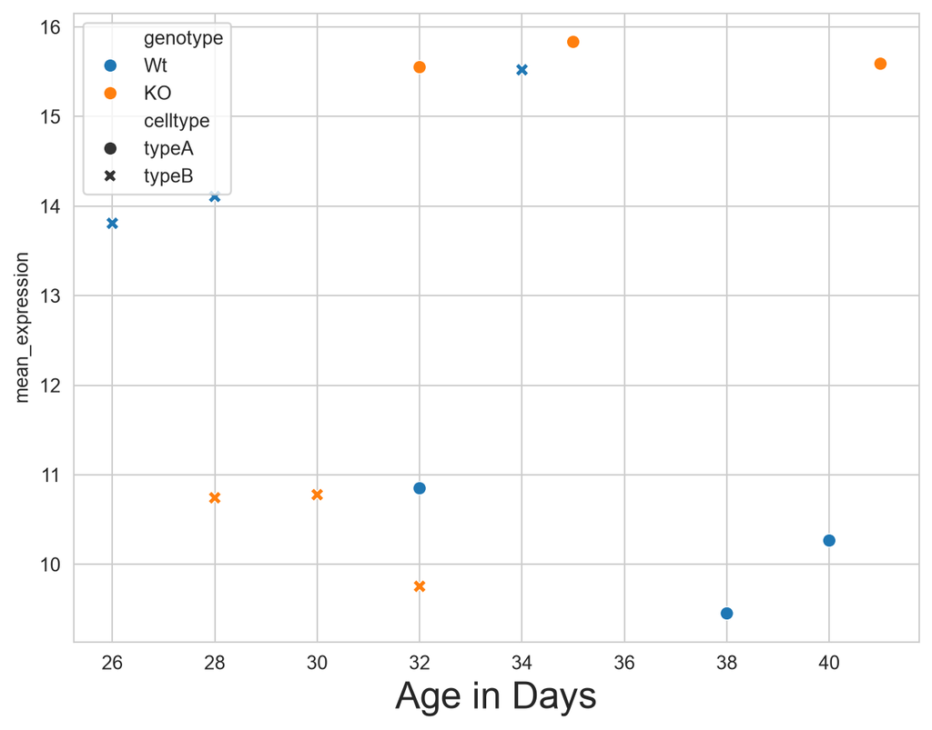

Figure 8: Scatterplot of age in days vs. mean expression, colored by genotype and shaped by celltype, with adjusted size, a different theme and larger x-axis title.

```python
# Set the theme to "whitegrid"
sns.set_style(style = "whitegrid")

# Initialize a plot with a specific size
plt.figure(figsize = (8, 6))

# Add a scatterplot layer to the plot, coloring points by genotype
sns.scatterplot(data = new_metadata,
                x = "age_in_days",
                y = "mean_expression",
                hue = "genotype",
                style = "celltype",
                s = 50)

# Change the size and text of the axis label
plt.xlabel(xlabel = "Age in Days",
           fontsize = 20)

# Render the plot
plt.show()
```

## Saving plots

If you wanted to save this plot, you can use the `savefig()` function from `matplotlib` and specify the file name and format you want to save it in. By default, this function will save the last plot that was generated in a given code block, so make sure to call `savefig()` after you have generated the plot you want to save in the same codeblock. For example, to save the plot as a PNG file, you can use:

```python
# Set the theme to "whitegrid"
sns.set_style(style = "whitegrid")

# Initialize a plot with a specific size
plt.figure(figsize = (8, 6))

# Add a scatterplot layer to the plot, coloring points by genotype
sns.scatterplot(data = new_metadata,
                x = "age_in_days",
                y = "mean_expression",
                hue = "genotype",
                style = "celltype",
                s = 50)

# Change the size and text of the axis label
plt.xlabel(xlabel = "Age in Days",
           fontsize=20)

# Save the plot as a PNG file
plt.savefig(fname = "figures/scatterplot.png",
            format = "png")
```

If you wanted to specify the resolution (DPI) or the size of the saved figure, you can also include those arguments in the `savefig()` function. For example, to save the plot as a PNG file with a resolution of 300 DPI we can use:

```python
# Set the theme to "whitegrid"
sns.set_style(style = "whitegrid")

# Initialize a plot with a specific size
plt.figure(figsize = (8, 6))

# Add a scatterplot layer to the plot, coloring points by genotype
sns.scatterplot(data = new_metadata,
                x = "age_in_days",
                y = "mean_expression",
                hue = "genotype",
                style = "celltype",
                s = 50)

# Change the size and text of the axis label
plt.xlabel(xlabel = "Age in Days",
           fontsize = 20)

# Save the plot as a PNG file with specific DPI and size
plt.savefig(fname = "figures/scatterplot_dpi.png",
            format = "png",
            dpi = 300)
```

**Tip**Exercise 1**

1. Add a `plt.ylabel()` layer to the current plot such that the y-axis is labeled “Mean expression”.
2. Use the `plt.title()` layer to add a plot title of your choice.
3. When you add the arguments `loc="right"` to the `plt.title()` function, what does it change?
4. Let’s remove the `loc = "right"` argument from `plt.title()`. Try adding the layer `plt.legend(loc = "center right")` to the end of your code. What does this do? How many layers can be added to a plot, in your estimation?

Next Lesson >>

Back to Schedule